# EP03-respuesta-equipo-07

2026-10-08

**Pregunta 1:**

El jefe de calidad rechazará que el calibre medio es 28 mm si la media de la muestra es menor que 27,62 mm o mayor que 28,38 mm. Supongan que el verdadero calibre medio es 28,55 mm. Hagan un gráfico con las dos distribuciones muestrales, la hipotética y la verdadera, y marquen y calculen α y β. ¿Qué significa, para la exportadora, cometer un error de tipo II en este caso?

**Hipótesis:**

- Hipótesis nula ($H_0$): El calibre medio poblacional de las cerezas es igual a 28 mm.
- Hipótesis alternativa ($H_A$): El calibre medio poblacional de las cerezas es distinto de 28 mm.

**matemáticamente:** * $H_0: \mu = 28$ * $H_A: \mu \neq 28$

Partiremos graficando la distribución muestral

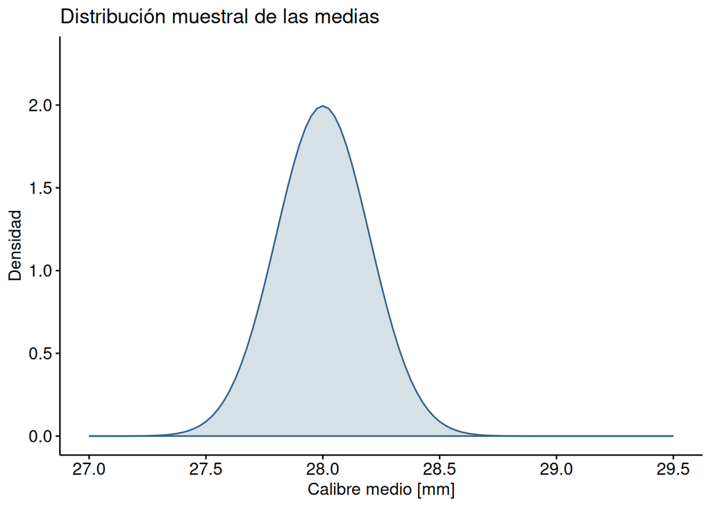

Una vez graficada la distribución muestral, agregamos las regiones críticas

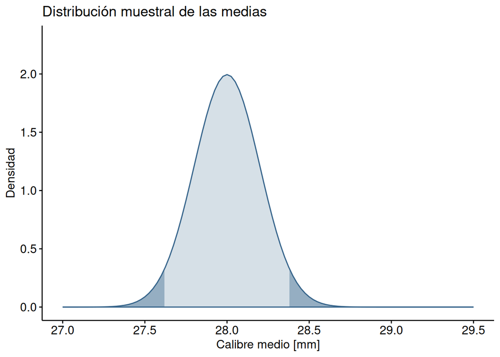

Luego agregamos la distribución real y mostramos el tamaño del efecto

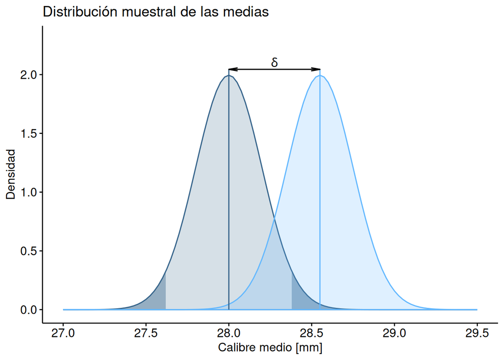

Finalmente, mostramos alpha y beta en el gráfico

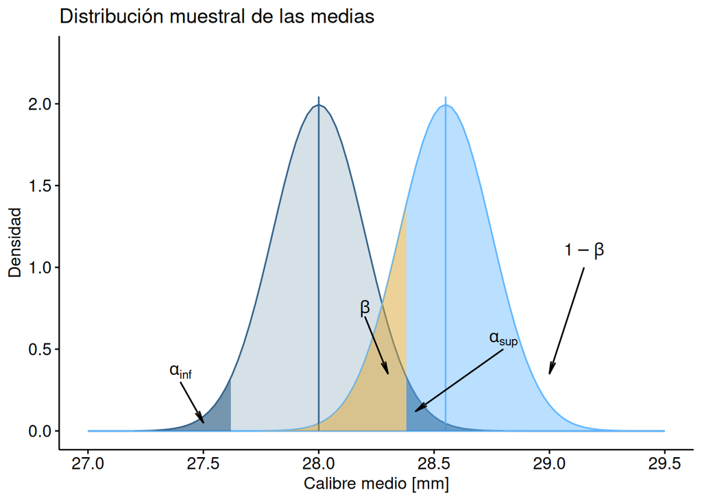

```
## Alfa =  0.05743312
```

```
## Poder =  0.8023391
```

```
## Beta =  0.1976609
```

Se debe aclarar que el poder inferior existe, pero es prácticamente cero para $\mu$ = 28,55.

Cometer un error de tipo II en este caso significa no rechazar la hipótesis nula cuando es falsa, es decir, la exportadora concluye que el calibre medio de las cerezas sigue siendo 28 mm cuando en realidad la producción tiene un calibre superior de 28,55 mm. Por lo tanto, la exportadora no detecta la diferencia real y terminaría exportando la fruta con un calibre equivocado.

**Pregunta 2:**

Hagan el gráfico del poder de esta prueba suponiendo que el verdadero calibre medio puede ir de 27 a 29 mm. ¿Cuánto vale el poder cuando el calibre medio es exactamente 28 mm? ¿Por qué?

Estableciendo las hipotesis

H0: $\mu$ = 28 mm. El calibre medio poblacional de las cerezas es igual a 28 mm.

HA: $\mu$ != 28 mm. El calibre medio poblacional de las cerezas es distinto de 28 mm.

```
## Poder = 0.8023391
```

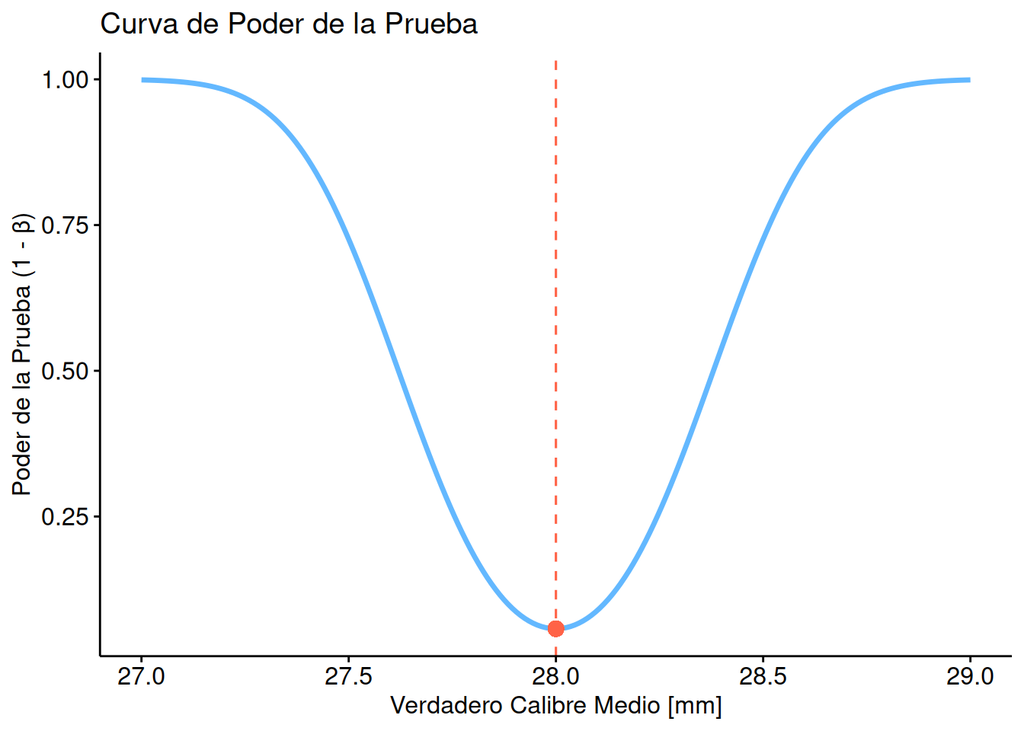

```
## Poder cuando el calibre medio es exatamente de 28 mm:  0.05743312
```

Notemos que el poder del calibre medio cuando es exactamente de 28 mm es de 0,05743312.

Recordemos que el poder se define como “La probabilidad de rechazar la hipotesis nula de H0 dados los limites criticos establecidos”. Si el verdadero calibre medio es igual a la medida propuesta H0 = 28 mm, rechaza H0 ya no es una decision correcta, sino un error de tipo 1 que seria rechazar la hipotesis nula que es verdadera. Por lo tanto, calcular la probabilidad de caer en una zona de rechazo cuando μ = 28 es matematicamente identico que calcular el valor de α.

**Pregunta 3:**

Si el verdadero calibre medio fuera 28,55 mm, ¿cuántas cerezas habría que medir para tener un poder de 0,7 con α = 0,05?

```
##
##      Mean power calculation for normal distribution with known variance
##
##               d = 0.275
##               n = 81.61328
##       sig.level = 0.05
##           power = 0.7
##     alternative = two.sided
```

```
## n: 82
```

Por lo tanto el numero de cerezas que habría que medir para tener un poder de 0,7 con α = 0,05 es de 82 cerezas.

**Pregunta 4:**

El jefe de calidad cree que alrededor del 91 % de las cerezas del huerto tecnificado son de calibre exportable, contra el 82 % del tradicional. Supongan que las cerezas de la pregunta 3 se reparten en partes iguales entre los dos huertos. ¿Alcanza esa muestra para detectar la diferencia que el jefe de calidad cree que hay entre los huertos, con el mismo nivel de significación (0,05) y un poder de al menos 0,8? Si no alcanza, ¿cuántas cerezas de cada huerto harían falta?

Como las cerezas de la pregunta 3 son 82, entonces podemos repartirlas entre los dos huertos, quedando 41 cerezas para cada huerto

Aclaración: Se va a usar una prueba bilateral de dos proporciones independientes, ya que el enunciado pide determinar si la muestra permite detectar una diferencia entre las proporciones de cerezas exportables de ambos huertos, sin indicar explícitamente que se tenga que comprobar que una proporción es mayor que la otra. Por eso se eligió la prueba bilateral, para ver si la muesta permite detectar una posible diferencia que plantea el jefe de calidad.

H0: pt = pr. La proporción poblacional de cerezas de calibre exportable es igual en el huerto tecnificado y en el huerto tradicional.

H1: pt != pr. La proporción poblacional de cerezas de calibre exportable es distinta entre ambos huertos.

(pt = proporción huerto tecnificado, pr = proporción huerto tradicional)

```
##
##      Difference of proportion power calculation for binomial distribution (arcsine transformation)
##
##               h = 0.2669128
##               n = 41
##       sig.level = 0.05
##           power = 0.2269526
##     alternative = two.sided
##
## NOTE: same sample sizes
```

```
## Poder alcanzable con n = 41 por cada muestra:  0.2269526
```

Podemos ver que el poder alcanzable con 41 cerezas por cada muestra no nos permite tener por lo menos un 0,8 de poder, ya que solo se puede obtener un 0.2269526 de poder, por lo tanto, debemos calcular lo que nos falta para lograr 0,8.

```
##
##      Difference of proportion power calculation for binomial distribution (arcsine transformation)
##
##               h = 0.2669128
##               n = 220.3423
##       sig.level = 0.05
##           power = 0.8
##     alternative = two.sided
##
## NOTE: same sample sizes
```

```
## Tamaño de las muestras necesario:  221
```

Es posible ver que el tamaño necesario para obtener como mínimo un poder de al menos 0,8 es 221, por lo tanto faltan 180 (221 - 41) cerezas más en cada muestra para obtener al menos un 0,8 de poder en esta prueba.